# Vincent

Shoe classifier Converse, Vans, Nike, Addidas

## Create folder

```python
from fastai.vision import *
```

```python
path = Path('data/shoes')
classes = ['converse','vans','nike','addidas'];
```

```python
for c in classes:
    #create folders for each class
    folder = c
    file = c + '.csv'
    dest = path/folder
    dest.mkdir(parents=True, exist_ok=True)
```

```python
path.ls()
```

```
[PosixPath('data/shoes/.ipynb_checkpoints'),
 PosixPath('data/shoes/addidas'),
 PosixPath('data/shoes/converse'),
 PosixPath('data/shoes/models'),
 PosixPath('data/shoes/nike'),
 PosixPath('data/shoes/vans'),
 PosixPath('data/shoes/cleaned.csv'),
 PosixPath('data/shoes/export.pkl')]
```

## Download images

```python
for c in classes:
    download_images(path/c/(c + '.csv'), path/c, max_pics=200)
```

```python
for c in classes:
    verify_images(path/c, delete=True, max_size=500)
```

## View data

```python
np.random.seed(42)
data = ImageDataBunch.from_folder(path, train=".", valid_pct=0.2,
        ds_tfms=get_transforms(), size=224, num_workers=4).normalize(imagenet_stats)
```

```python
# If you already cleaned your data, run this cell instead of the one before
np.random.seed(42)
data = ImageDataBunch.from_csv(path, folder=".", valid_pct=0.2, csv_labels='cleaned.csv',
         ds_tfms=get_transforms(), size=224, num_workers=4).normalize(imagenet_stats)
```

Good! Let's take a look at some of our pictures then.

```python
data.classes
```

```
['addidas', 'converse', 'nike', 'vans']
```

[figure not shown]

```python
data.show_batch(rows=3, figsize=(7,8))
```

```python
data.classes, data.c, len(data.train_ds), len(data.valid_ds)
```

```
(['addidas', 'converse', 'nike', 'vans'], 4, 372, 92)
```

## Train model

```python
learn = cnn_learner(data, models.resnet34, metrics=error_rate)
```

```python
learn.fit_one_cycle(12)
```

| epoch | train_loss | valid_loss | error_rate | time |
| --- | --- | --- | --- | --- |
| 0 | 2.523134 | 3.281027 | 0.836957 | 00:02 |
| 1 | 2.144896 | 1.794670 | 0.684783 | 00:02 |
| 2 | 1.801644 | 1.342001 | 0.434783 | 00:02 |
| 3 | 1.537475 | 1.185771 | 0.369565 | 00:02 |
| 4 | 1.333652 | 1.101417 | 0.347826 | 00:02 |
| 5 | 1.162424 | 1.087076 | 0.358696 | 00:02 |
| 6 | 1.060597 | 1.041111 | 0.358696 | 00:02 |
| 7 | 0.949072 | 0.965374 | 0.336957 | 00:02 |
| 8 | 0.872508 | 0.910972 | 0.304348 | 00:02 |
| 9 | 0.789894 | 0.891400 | 0.282609 | 00:02 |
| 10 | 0.737810 | 0.887123 | 0.282609 | 00:02 |
| 11 | 0.678247 | 0.875090 | 0.293478 | 00:02 |

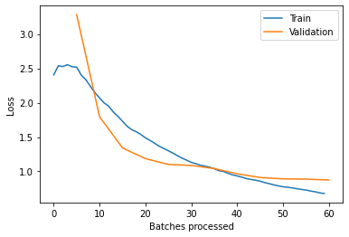

```python
learn.recorder.plot_losses();
```

```python
learn.save('stage-1')
```

```python
learn.unfreeze()
```

```python
learn.lr_find()
```

75.00% [15/20 00:32<00:10]

| epoch | train_loss | valid_loss | error_rate | time |
| --- | --- | --- | --- | --- |
| 0 | 0.352674 | #na# | 00:02 |  |
| 1 | 0.321781 | #na# | 00:02 |  |
| 2 | 0.316649 | #na# | 00:02 |  |
| 3 | 0.345485 | #na# | 00:02 |  |
| 4 | 0.340436 | #na# | 00:02 |  |
| 5 | 0.335269 | #na# | 00:02 |  |
| 6 | 0.328293 | #na# | 00:02 |  |
| 7 | 0.302345 | #na# | 00:02 |  |
| 8 | 0.294813 | #na# | 00:02 |  |
| 9 | 0.273760 | #na# | 00:02 |  |
| 10 | 0.319409 | #na# | 00:02 |  |
| 11 | 0.557431 | #na# | 00:02 |  |
| 12 | 0.694441 | #na# | 00:02 |  |
| 13 | 0.804905 | #na# | 00:02 |  |
| 14 | 0.958035 | #na# | 00:02 |  |

20.00% [1/5 00:01<00:04 0.9979]

```
LR Finder is complete, type {learner_name}.recorder.plot() to see the graph.
```

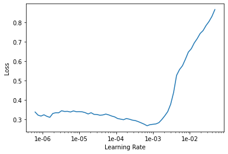

```python
# If the plot is not showing try to give a start and end learning rate
#learn.lr_find(start_lr=1e-6, end_lr=1e-3)
learn.recorder.plot()
```

```python
learn.load("stage-1");
learn.fit_one_cycle(8, max_lr=3e-4);
```

| epoch | train_loss | valid_loss | error_rate | time |
| --- | --- | --- | --- | --- |
| 0 | 0.413782 | 0.860560 | 0.282609 | 00:02 |
| 1 | 0.334072 | 0.927705 | 0.228261 | 00:02 |
| 2 | 0.278449 | 1.400349 | 0.293478 | 00:02 |
| 3 | 0.274249 | 1.389940 | 0.315217 | 00:02 |
| 4 | 0.272492 | 1.024005 | 0.228261 | 00:02 |
| 5 | 0.261700 | 0.979407 | 0.195652 | 00:03 |
| 6 | 0.233709 | 0.996741 | 0.184783 | 00:02 |
| 7 | 0.213395 | 0.949109 | 0.184783 | 00:02 |

```python
doc(learn.fit_one_cycle)
```

[figure not shown]

```python
learn.recorder.plot_lr();
```

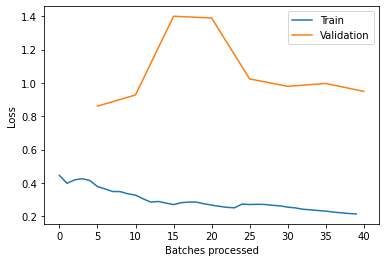

```python
learn.recorder.plot_losses();
```

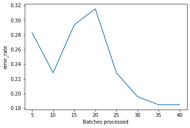

```python
learn.recorder.plot_metrics();
```

[output not shown]

```python
learn.save('stage-2')
```

## Interpretation

```python
learn.load('stage-2');
```

```python
interp = ClassificationInterpretation.from_learner(learn)
```

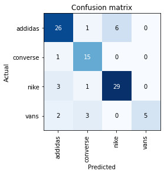

```python
interp.plot_confusion_matrix()
```

[figure not shown]

```python
interp.plot_top_losses(9, figsize=(15,11))
```

## Cleaning Up

Some of our top losses aren't due to bad performance by our model. There are images in our data set that shouldn't be.

Using the `ImageCleaner` widget from `fastai.widgets` we can prune our top losses, removing photos that don't belong.

```python
from fastai.widgets import *
```

First we need to get the file paths from our top_losses. We can do this with `.from_toplosses`. We then feed the top losses indexes and corresponding dataset to `ImageCleaner`.

Notice that the widget will not delete images directly from disk but it will create a new csv file `cleaned.csv` from where you can create a new ImageDataBunch with the corrected labels to continue training your model.

In order to clean the entire set of images, we need to create a new dataset without the split. The video lecture demostrated the use of the `ds_type` param which no longer has any effect. See [the thread](https://forums.fast.ai/t/duplicate-widget/30975/10) for more details.

```python
db = (ImageList.from_folder(path)
                   .split_none()
                   .label_from_folder()
                   .transform(get_transforms(), size=224)
                   .databunch()
     )
```

```python
# If you already cleaned your data using indexes from `from_toplosses`,
# run this cell instead of the one before to proceed with removing duplicates.
# Otherwise all the results of the previous step would be overwritten by
# the new run of `ImageCleaner`.

# db = (ImageList.from_csv(path, 'cleaned.csv', folder='.')
#                    .split_none()
#                    .label_from_df()
#                    .transform(get_transforms(), size=224)
#                    .databunch()
#      )
```

Then we create a new learner to use our new databunch with all the images.

```python
learn_cln = cnn_learner(db, models.resnet34, metrics=error_rate)

learn_cln.load('stage-2');
```

```python
ds, idxs = DatasetFormatter().from_toplosses(learn_cln)
```

Make sure you're running this notebook in Jupyter Notebook, not Jupyter Lab. That is accessible via /tree, not /lab. Running the `ImageCleaner` widget in Jupyter Lab is [not currently supported](https://github.com/fastai/fastai/issues/1539).

```python
# Don't run this in google colab or any other instances running jupyter lab.
# If you do run this on Jupyter Lab, you need to restart your runtime and
# runtime state including all local variables will be lost.
ImageCleaner(ds, idxs, path)
```

If the code above does not show any GUI(contains images and buttons) rendered by widgets but only text output, that may caused by the configuration problem of ipywidgets. Try the solution in this [link](https://github.com/fastai/fastai/issues/1539#issuecomment-505999861) to solve it.

Flag photos for deletion by clicking 'Delete'. Then click 'Next Batch' to delete flagged photos and keep the rest in that row. `ImageCleaner` will show you a new row of images until there are no more to show. In this case, the widget will show you images until there are none left from `top_losses.ImageCleaner(ds, idxs)`

Remember to recreate your ImageDataBunch from your `cleaned.csv` to include the changes you made in your data!

## Putting your model in production

First thing first, let's export the content of our `Learner` object for production:

```python
learn.export()
```

This will create a file named 'export.pkl' in the directory where we were working that contains everything we need to deploy our model (the model, the weights but also some metadata like the classes or the transforms/normalization used).

You probably want to use CPU for inference, except at massive scale (and you almost certainly don't need to train in real-time). If you don't have a GPU that happens automatically. You can test your model on CPU like so:

```python
defaults.device = torch.device('cpu')
```

[figure not shown]

```python
img = open_image(path/'converse'/'00000001.jpg')
img
```

We create our `Learner` in production enviromnent like this, just make sure that `path` contains the file 'export.pkl' from before.

```python
learn = load_learner(path)
```

```python
pred_class,pred_idx,outputs = learn.predict(img)
pred_class.obj
```

```
'converse'
```